# Problem Set 2

# Introduction

### This .Rmd file will be used to analyze a Halloween dataset by practicing skills and fuctions learned throughout chapters 2-4 in the book Getting Started With R

## Getting set up

```r
rm(list = ls()) # clears R's brain
library(dplyr) #library() activates the specified packages
library(ggplot2)
library(here)
```

## Pulling in the data

```r
Halloween <- read.csv(here("Data", "Halloween_data_PS2.csv"), stringsAsFactors = TRUE)
glimpse(Halloween)
```

```
Rows: 46
Columns: 4
$ Costume      <fct> wonder woman, wonder woman, Wonder Woman, Wonder woman, wonder…
$ Type         <fct> Not scary, Not scary, Not scary, Not scary, Not scary, Not sca…
$ candy_pieces <int> 2, 1, 1, 3, 2, 1, 1, 1, 4, 3, 4, NA, 3, 1, 1, 1, 1, 2, 1, 1, 2…
$ age          <int> 8, 9, 10, NA, 8, 9, 10, 10, 14, 13, 12, 14, 13, 7, 8, 6, 7, 8,…
```

## Tidying the data

### Some of the values under the column heading “Costume” do not follow data formatting priciples. In order to generate accurate analyses, the values need to be uniform in spelling and capitalizations.

```r
str(Halloween)
```

```
'data.frame':   46 obs. of  4 variables:
 $ Costume     : Factor w/ 15 levels "clown","creepy clown",..: 12 12 14 13 12 12 13 13 2 1 ...
 $ Type        : Factor w/ 4 levels "Not scary","scary",..: 1 1 1 1 1 1 1 1 3 3 ...
 $ candy_pieces: int  2 1 1 3 2 1 1 1 4 3 ...
 $ age         : int  8 9 10 NA 8 9 10 10 14 13 ...
```

```r
levels(Halloween$Costume)
```

```
 [1] "clown"        "creepy clown" "Creepy clown" "Mermaid"      "Mouse"
 [6] "pirate"       "Rabbit"       "Unicorn"      "witch"        "Witch"
[11] "witch "       "wonder woman" "Wonder woman" "Wonder Woman" "Zombie"
```

```r
witch <- which(Halloween$Costume == "witch " | Halloween$Costume == "witch" | Halloween$Costume == "Witch") #consolidates all versions of the same response
Halloween$Costume[witch] <- "witch" #assigns the various responses to one response
wonder <- which(Halloween$Costume == "wonder woman" | Halloween$Costume == "Wonder woman"| Halloween$Costume == "Wonder Woman")
Halloween$Costume[wonder] <- "wonder woman"
clown <- which(Halloween$Costume == "Creepy clown" | Halloween$Costume == "creepy clown" | Halloween$Costume == "clown")
Halloween$Costume[clown] <- "clown"
```

See if the levels have been correctly reestablished.

```r
Halloween$Costume <- factor(Halloween$Costume) #resets factor levels
levels(Halloween$Costume) #pulls the levels
```

```
[1] "clown"        "Mermaid"      "Mouse"        "pirate"       "Rabbit"
[6] "Unicorn"      "witch"        "wonder woman" "Zombie"
```

Check the levels for the ‘Type’ column. This column should be Binary with the options ‘Scary’ or ‘Not scary’

```r
levels(Halloween$Type)
```

```
[1] "Not scary" "scary"     "Scary"     "scary "
```

There are some data formatting issues in the ‘Type’ column. Fix the level errors

```r
Scary <- which(Halloween$Type == "scary" | Halloween$Type == "Scary" | Halloween$Type == "scary ")
Halloween$Type[Scary] <- "Scary"
Halloween$Type <- factor(Halloween$Type)
levels(Halloween$Type)
```

```
[1] "Not scary" "Scary"
```

Now that the data is fixed, it is ready to be worked with. First, a calculation of the mean age and mean number of candy taken needs to be calculated for each costume.

```r
means <- Halloween %>%
  group_by(Costume, Type) %>% summarise(meanage = mean(age, na.rm = TRUE), meancandy = mean(candy_pieces, na.rm = TRUE))
```

[output not shown]

With the means calculated, a scatterplot can now to generated.

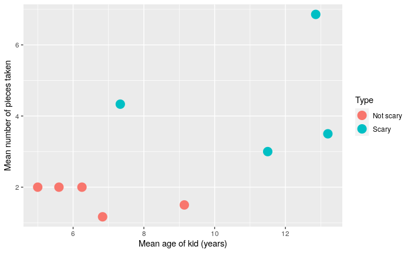

```r
ggplot(means, aes(x = meanage, y = meancandy, color = Type)) +
  geom_point(size = 5) + xlab("Mean age of kid (years)") + ylab("Mean number of pieces taken")
```

```r
notscarykids <- filter(Halloween, Type == 'Not scary' | age < 10)
```

Create a histogram with the notscarykids subset

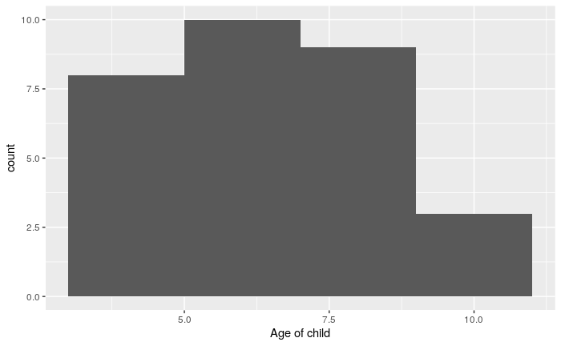

```r
ggplot(notscarykids, aes(x = age)) + xlab("Age of child") + geom_histogram(bins = 4)
```

```r
NA
```

Generate a side by side box plot of costume type with costume choice and age.

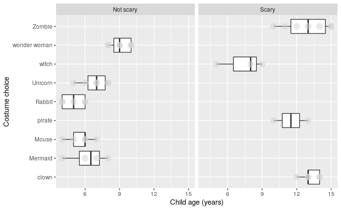

```r
ggplot(Halloween, aes(x = Costume, y = age)) + coord_flip() +
  geom_boxplot() +
  geom_point(size = 4, colour = 'lightgrey', alpha = 0.5) +
  xlab("Costume choice") +
  ylab("Child age (years)") +
  facet_wrap(~Type) #creates two plots sorted by costume type +
```

```r
  theme_bw()
```

[output not shown]

[output cut: 365 more lines]

[output not shown]